# Data Warehouse

The most commonly utlized schema for datawarehouse modeling are star and snowflake schema Star schema required de-normaliation at the ETL layer and hence more time whereas Snowflake schema increases dimension complexity and hence more time fro Analytics query.

For the current case, snowflake schema was selected to model the DWH. The choice is highly depndent on the information that we want to preserve. In our dataset there are a lot of movie ratings and user tags that change over the time. If we were not interested in this information, a star schema with 4 tables would have suffied. To capture more information, a snowflake schema was selected.

How to select the fact and dimension. Fact table usually contains the business facts, whereas the dimesnion table contains the description of this fact. In this regard, the snowflake schema for the dataset is presented below.

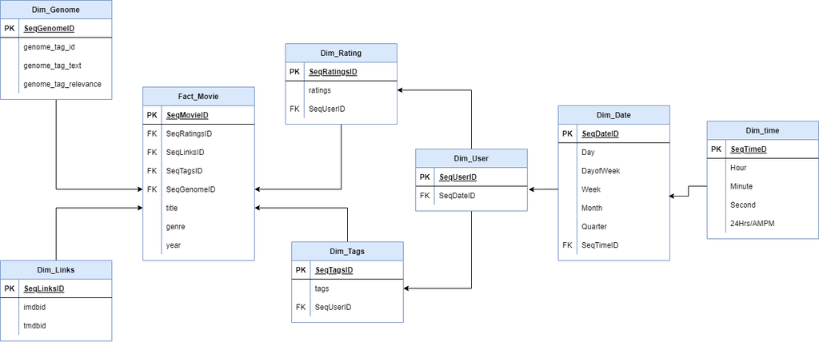

```python
from IPython import display
display.Image("./images/ERM_DWH_SnowFlake.png")
```

In this project, we have used sqlite, which is not a good scalable option for the DWH. Due to single file system nd ease of locally working, it was selected. Any good service like Postgres SQL and MySQL should be able to handle and scale 100 million records based on the proposed schema. Similarly, right now, due to cheap cloud based columnar data warehouses, scaling, storage and storage cost are mutable.

```python
import os
os.system('jupyter nbconvert --to html Task_3_DWH.ipynb')
```

```
0
```